# HHL Algorithm Implementation in Qiskit - State Preparation

Python

Quantum Computing

A step-by-step implementation of the state-preparation stage of the HHL algorithm using Qiskit.

Author

Qingsen Zhang

Published

January 15, 2025

# HHL Algorithm Implementation in Qiskit

## Introduction

This document provides a step-by-step implementation of the HHL algorithm using Qiskit. The algorithm is broken into four key phases:

1. ***State Preparation**
2. **Quantum Phase Estimation (QPE)**
3. **Controlled Rotation & Measurement of the Ancilla Qubit**
4. **Uncomputation (Inverse QPE)**

## Phase 0: Environment Setup

### Overall

$A\vec{x}=\vec{b}~~\rightarrow~~\vec{x}=A^{-1}\vec{b}$  
The goal is to get $\vec{x}$

$|x\rangle = A^{-1}|b\rangle=\sum\limits^{N-1}_{j=0}b_jA^{-1}|u_j\rangle=\sum\limits^{N-1}_{j=0}\frac{b_j}{\lambda_j}|u_j\rangle$
$$\begin{aligned}
&~~~~~~A|u_j\rangle = \lambda_j|u_j\rangle \\
&\rightarrow A^{-1}A|u_j\rangle = A^{-1}\lambda_j|u_j\rangle \\
&\rightarrow |u_j\rangle = A^{-1}\lambda_j|u_j\rangle \\
&\rightarrow A^{-1}|u_j\rangle = \frac{1}{\lambda_j}|u_j\rangle
\end{aligned}$$

### Numerical Example

$A=\begin{bmatrix}1 & -\frac{1}{3}\\-\frac{1}{3} & 1\end{bmatrix}$  
$\vec{b}=\begin{bmatrix}0\\1\end{bmatrix}$

- eigenvalue and eigenvecter

```python
A = np.array([[1, -1/3], [-1/3, 1]])
eigenvalues, eigenvectors = np.linalg.eig(A)
print(f"eigenvalues:\n{np.round(eigenvalues,2)}")
print(f"eigenvectors:\n{np.round(eigenvectors,2)}")

# Verify the eigenvalue-eigenvector relationship
assert np.allclose(np.dot(A, eigenvectors.T[0]), eigenvalues[0] * eigenvectors.T[0])
assert np.allclose(np.dot(A, eigenvectors.T[1]), eigenvalues[1] * eigenvectors.T[1])
```

```
eigenvalues:
[1.33+0.j 0.67+0.j]
eigenvectors:
[[ 0.71+0.j  0.71+0.j]
 [-0.71+0.j  0.71+0.j]]
```

```python
### The eigenvalue and eigenvectors given by paper
A = np.array([[1, -1/3], [-1/3, 1]])
b = np.array([0,1])
eigenvalues = [2/3, 4/3]
eigenvectors = np.array([[-1/(2**0.5), -1/(2**0.5)],[-1/(2**0.5), 1/(2**0.5)]])

assert np.allclose(np.dot(A, eigenvectors.T[0]), eigenvalues[0] * eigenvectors.T[0])
assert np.allclose(np.dot(A, eigenvectors.T[1]), eigenvalues[1] * eigenvectors.T[1])
```

Therefore, the eigenvectors are $\vec{u_0}=\begin{bmatrix}-\frac{1}{\sqrt2}\\-\frac{1}{\sqrt2}\end{bmatrix}$ and $\vec{u_1}=\begin{bmatrix}-\frac{1}{\sqrt2}\\\frac{1}{\sqrt2}\end{bmatrix}$ The eigenvalues are $\lambda_0=\frac{2}{3}$, $\lambda_1=\frac{4}{3}$

### Variables

$n_b$: # of qubits in `b-register`

$N_b=2^{n_b}$: # of unknows (length of $\vec{b}$, $len(\vec{b})=len(\vec{x})$)

$n_c$: # of qubits in `c-register`

a larger $n_c$ results in higher accuracy when the encoding is not exact

$N=2^n$

```python
N_b = 2 # number of variables (b.shape[0])
n_b = int(np.log2(N_b)) # number of qubits in b-register
# n_b = 1 # N_b = 2^(n_b), n_b = np.log2(N_b)
n_c = 1 # number of qubits in c-register
N_c = 2 # N_c = 2^(n_c)
```

### Propreties

$A$ is $N_b \times N_b$ Hermitian matrix

HHL is $O(\log(N))$

## Phase 1: State Preparation

### Initial State

Given $n_b$, $n_c$, there are total $n_b+n_c+1$ qubits
$$\begin{align}
|\psi_0\rangle &= |0\dots0\rangle_b|0\dots0\rangle_c|0\rangle_a \\
&= |0\rangle^{\otimes n_b}|0\rangle^{\otimes n}|0\rangle
\end{align}$$

```
Initial quantum circuit:
```

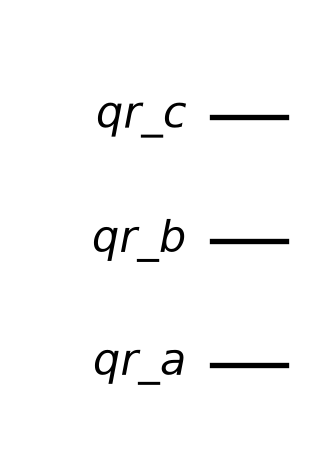

```python
from qiskit import QuantumRegister, QuantumCircuit, transpile
from qiskit_aer import Aer

qr_b = QuantumRegister(n_b, name='qr_b')  # b-register
qr_c = QuantumRegister(n_c, name='qr_c')  # c-register
qr_a = QuantumRegister(1, name='qr_a')    # a-register
qc = QuantumCircuit(qr_c, qr_b, qr_a)  # complete circuit
# Initialize the quantum circuitz
print("Initial quantum circuit:")
# print(qc.draw(output='text'))
qc.draw(output='mpl')
# latex_source = qc.draw(output='latex_source')
# print(latex_source)
```

### Prepare $|b\rangle$

In the state preparation, $|0\dots 0\rangle_b$ in the `b-register` needs to be rotated to have the amplitudes correspond to the coefficients of $\vec{b}$. $\vec{b}=\left(\begin{matrix}\beta_0\\\beta_1\\\vdots\\\beta_{N_b-1}\end{matrix}\right)\Leftrightarrow\beta_0|0\rangle+\beta_1|1\rangle+\dots+\beta_{N_b-1}|N_b-1\rangle=|b\rangle$ $|\psi_1\rangle=|b\rangle_b|0\dots0\rangle_c|0\rangle_a$

```
Statevector after initialization: Statevector([0.+0.j, 0.+0.j, 1.+0.j, 0.+0.j, 0.+0.j, 0.+0.j, 0.+0.j,
             0.+0.j],
            dims=(2, 2, 2))
```

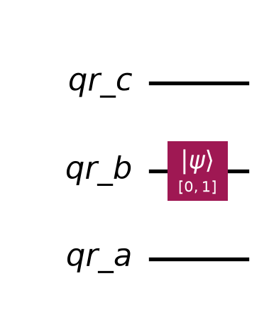

```python
# normalize b to make sure the aggregate possibility is 1
norm_b = b / np.linalg.norm(b)
qc.initialize(norm_b, qr_b)  # Apply to b-register


#----------Print states--------------------------------
# Simulate the circuit
simulator = Aer.get_backend('statevector_simulator')

# Transpile the circuit for the simulator
transpiled_circuit = transpile(qc, simulator)

# Run the transpiled circuit
result = simulator.run(transpiled_circuit).result()

# Extract the statevector
statevector = result.get_statevector(qc)
print("Statevector after initialization:", statevector)

# Optional: Visualize the circuit (if needed)
qc.draw(output='mpl')

#----------Print states--------------------------------
```

### All in one function

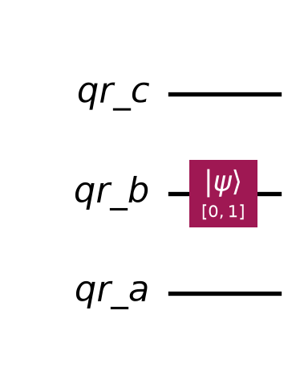

```python
def state_prep(mat_A, vec_b, n_c=1):
  N_b = vec_b.shape[0]
  n_b = int(np.log2(N_b))
  qr_b = QuantumRegister(n_b, name='qr_b')  # b-register
  qr_c = QuantumRegister(n_c, name='qr_c')  # c-register
  qr_a = QuantumRegister(1, name='qr_a')    # a-register
  qc = QuantumCircuit(qr_c, qr_b, qr_a)  # complete circuit

  norm_b = vec_b / np.linalg.norm(vec_b)
  qc.initialize(norm_b, qr_b)
  return qc, qr_b, qr_c, qr_a

mat_A = np.array([[1, -1/3], [-1/3, 1]])
vec_b = np.array([0,1])

psi_1, *_= state_prep(mat_A, vec_b, n_c=1)
psi_1.draw(output='mpl')
```

next step is Quantum Phase Estimation